# Item Fit

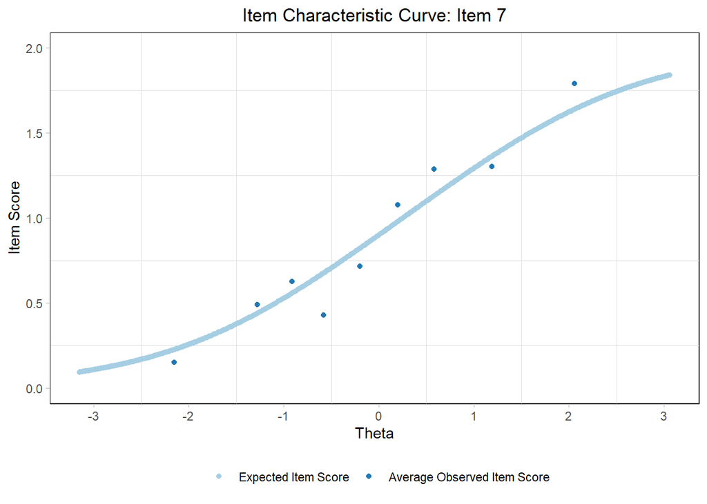

```r
ICCplot(data.srg, itemnumber = 7, method = "cut", cinumber = 9, title = "Item Characteristic Curve: Item 7")
```

These are two of the items that showed some overfit earlier. It can be noticed, that the increase in the observed scores (the dots) is somewhat steeper than the estimated ICC curve. That is commonly observed in presence of overfit.

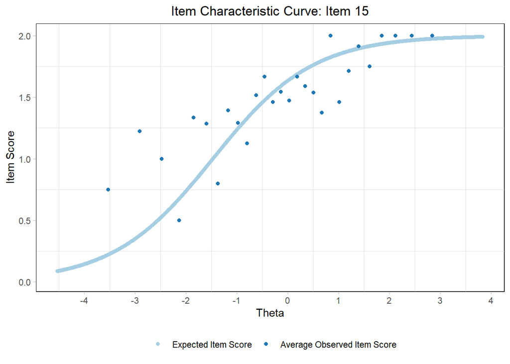

```r
ICCplot(data.srg, itemnumber = 15, method = "score", title = "Item Characteristic Curve: Item 15")
```

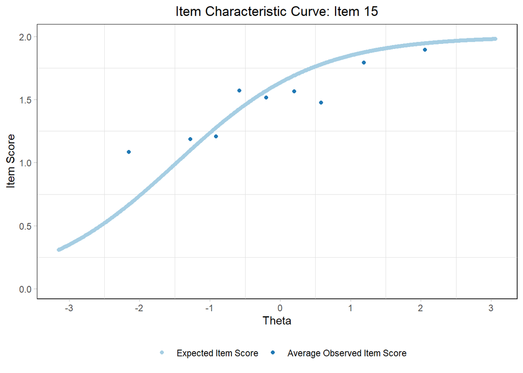

```r
ICCplot(data.srg, itemnumber = 15, method = "cut", cinumber = 9, title = "Item Characteristic Curve: Item 15")
```

The item 15 was the only item which was underfitting. It can be noticed, that the increase in the observed scores (the dots) is not consistently following the estimated ICC curve and that the observed change in observed score is flatter than predicted.

# Exercise

Smith (1998, p.78) suggests cut-off based on sample sizes. Have a look at the article in the Literature folder. Find and write down into R-code the two formulas and calculate the reasonable cut-offs for infit and outfit. Discuss item fit of the SRG-data under this light.

# References

Smith, R. M., R. E. Schumacker, and M. J. Bush. 1998. “Using Item Mean Squares to Evaluate Fit to the Rasch Model.” *J Outcome Meas* 2 (1): 66–78.

Wright, B. D., J. M. Linacre, J. E. Gustafson, and P. Martin-Loef. 1994. “Reasonable Mean-Square Fit Values.” *Rasch Measurement Transactions* 8 (3): 370.